# Math421_Assignment8

Louis Dion

10/28/2019

#### input anything we need for the assignment

```r
library(purrr)
library(tidyverse)
library(readxl)
titanic = read_csv('C:/Users/student/Documents/MATH421/data/titanic.csv')
titanic$Pclass = as.character(titanic$Pclass)
titanic$Survived = as.character(titanic$Survived)
```

1. Working with the Titanic dataset. Use the map function to compute the number of NA for each columns. Use map_int to turn the output to an interger vector.

```r
na<-map(titanic, ~sum(is.na(.)))
navector<-map_int(titanic,~sum(is.na(.)))
navector
```

```
## PassengerId    Survived      Pclass        Name         Sex         Age
##           0           0           0           0           0         177
##       SibSp       Parch      Ticket        Fare       Cabin    Embarked
##           0           0           0           0         687           2
```

2. Use map function to calculate the mean of numeric variables in the Titanic dataset.

```r
average<-titanic%>%select_if(is.numeric)%>%map(., ~mean(.,na.rm=TRUE))
average
```

```
## $PassengerId
## [1] 446
##
## $Age
## [1] 29.69912
##
## $SibSp
## [1] 0.5230079
##
## $Parch
## [1] 0.3815937
##
## $Fare
## [1] 32.20421
```

3. Use map function to show the means, medians, and standard deviations of numeric variables in the Titanic dataset. Use map_df to show the result in a data frame format.

```r
df<-titanic%>%select_if(is.numeric)%>%map(., ~list(
  mean =  mean(.x,na.rm=TRUE),
  median = median(.x,na.rm=TRUE),
  sd = sd(.x,na.rm=TRUE)))
df1<-titanic%>%select_if(is.numeric)%>%map_df(.,~list(
  mean =  mean(.x,na.rm=TRUE),
  median = median(.x,na.rm=TRUE),
  sd = sd(.x,na.rm=TRUE)))
df1$names<-colnames(titanic%>%select_if(is.numeric))

df1
```

```
## # A tibble: 5 x 4
##      mean median      sd names
##     <dbl>  <dbl>   <dbl> <chr>
## 1 446      446   257.    PassengerId
## 2  29.7     28    14.5   Age
## 3   0.523    0     1.10  SibSp
## 4   0.382    0     0.806 Parch
## 5  32.2     14.5  49.7   Fare
```

4. Use map function to show the mode (most frequent category) and the number of categories for each categorical variables. Put the result in data frame.

```r
#function to calculate mode in a vector
Mode = function(x){
    ta = table(x)
    tam = max(ta)
    if (all(ta == tam))
         mod = NA
    else
         if(is.numeric(x))
    mod = as.numeric(names(ta)[ta == tam])
    else
         mod = names(ta)[ta == tam]
    return(mod)
}

#using map
cat<-titanic%>%select_if(is.character)%>%map_df(.,~list(
  mode = Mode(.x)[1],
  categories = length(unique(.x))))
cat$names<-colnames(titanic%>%select_if(is.character))

cat
```

```
## # A tibble: 7 x 3
##   mode    categories names
##   <chr>        <int> <chr>
## 1 0                2 Survived
## 2 3                3 Pclass
## 3 <NA>           891 Name
## 4 male             2 Sex
## 5 1601           681 Ticket
## 6 B96 B98        148 Cabin
## 7 S                4 Embarked
```

5. Use map to graph the histograms of numeric variables and bar charts of categorical variables in the Titanic data

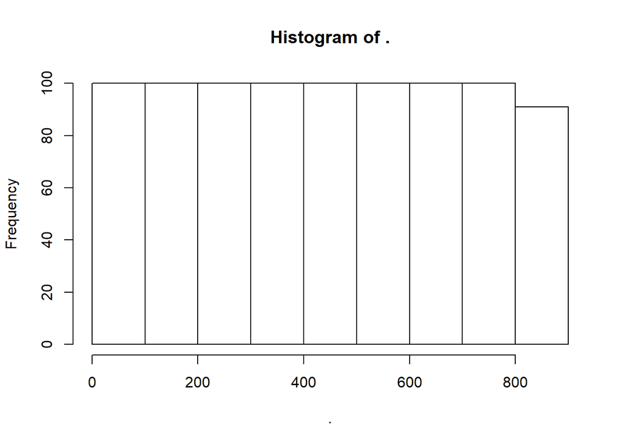

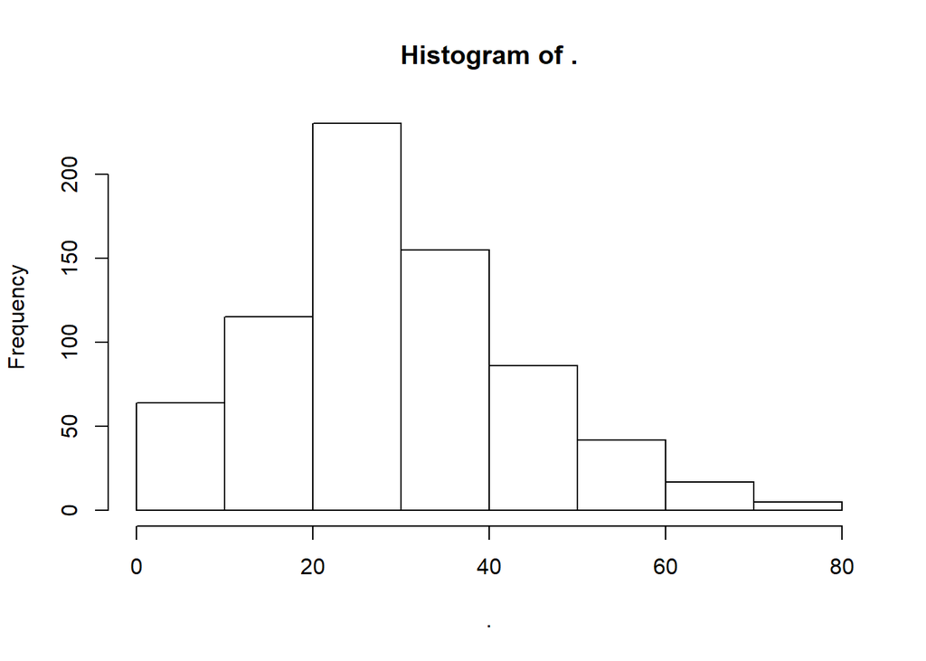

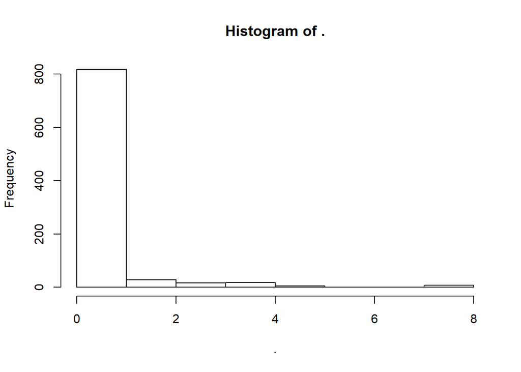

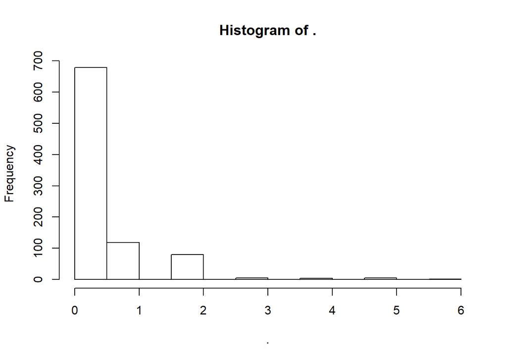

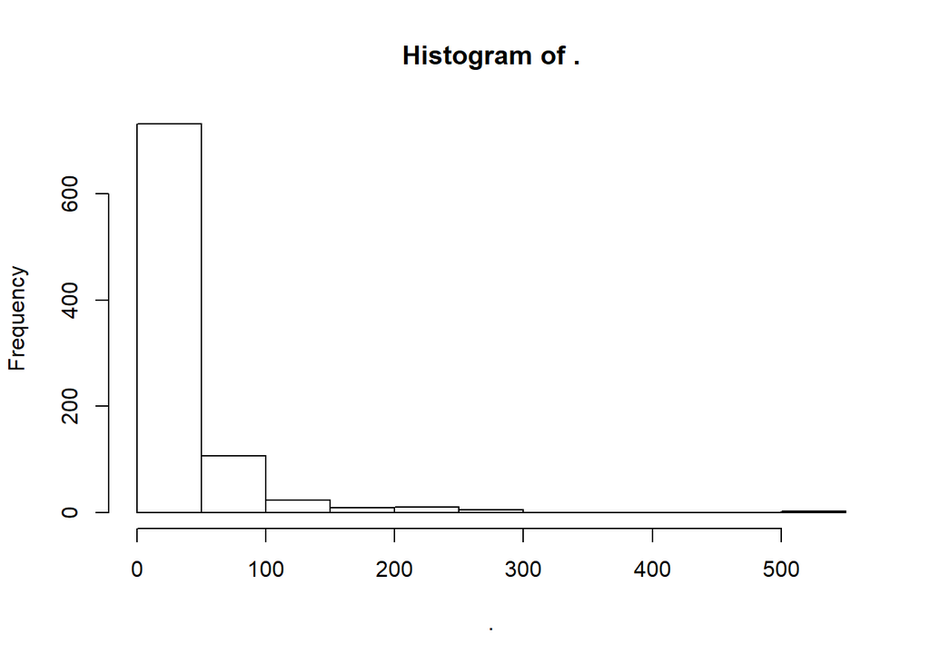

[output not shown]

[output cut: 61 more lines]

[output not shown]

```r
map(titanic%>%select_if(is.numeric),  ~hist(.))
```

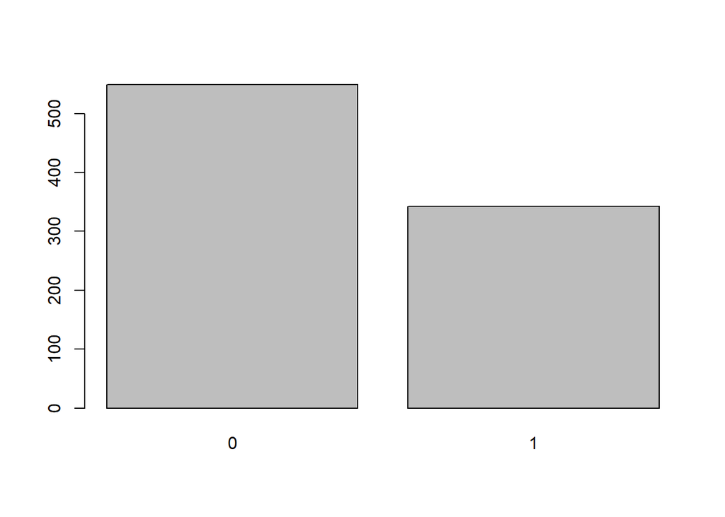

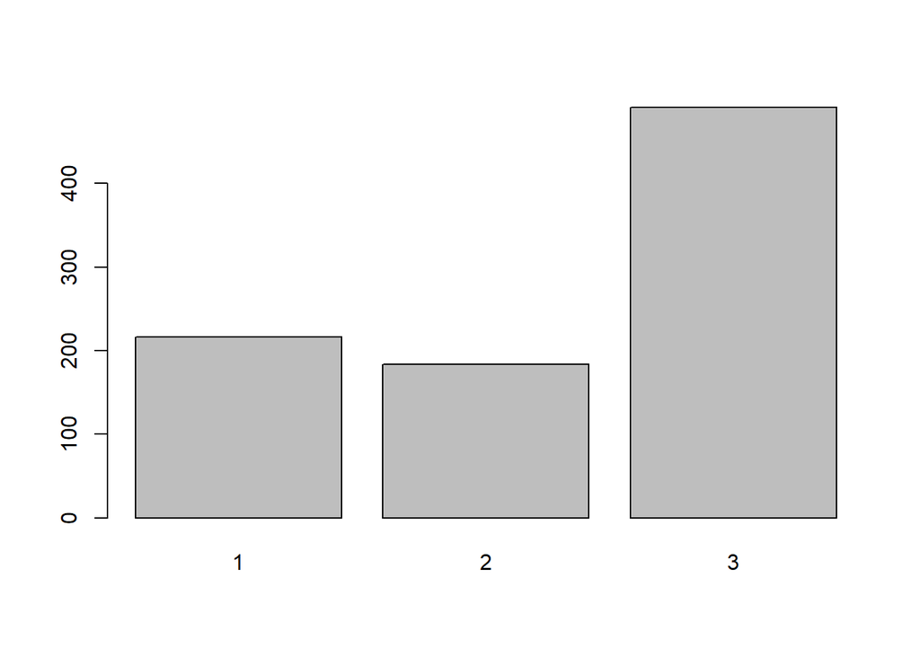

[figure not shown]

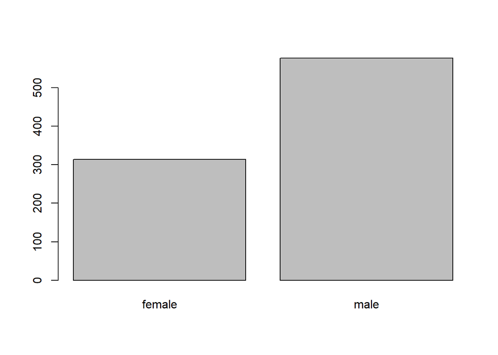

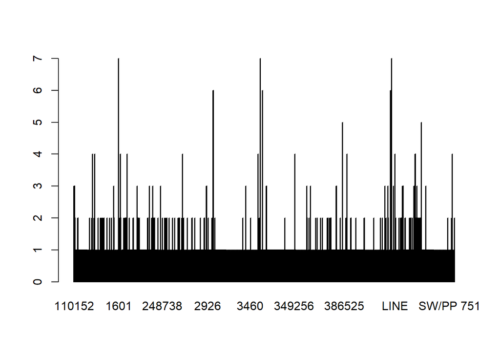

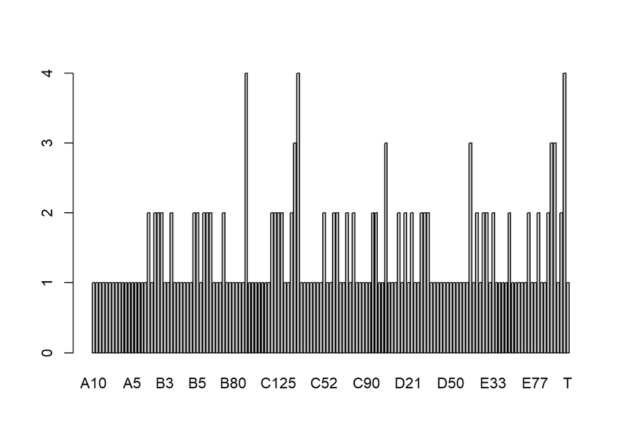

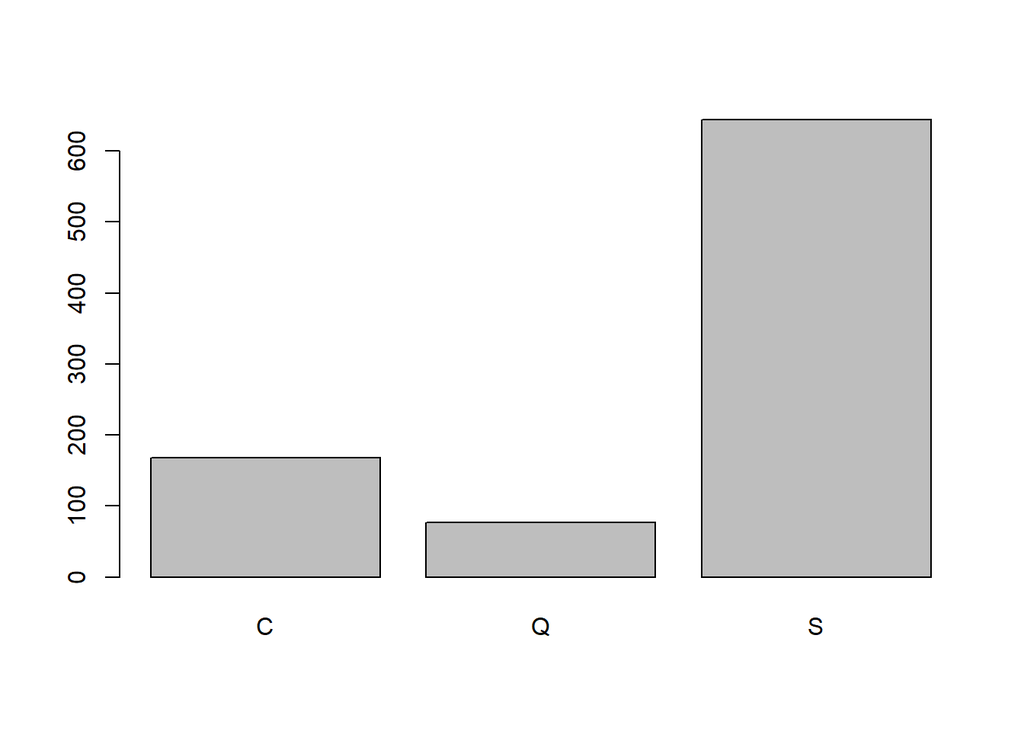

[output not shown]

[output cut: 1734 more lines]

```r
map(titanic%>%select_if(is.character),  ~barplot(table(.)))
```

6. Redo Question 11 in Assignment 7 using map. Hint: You may want to use a nested map. For instance this following codes print out all the possibility of x+y where both x and y are running from 1 to 2.

map(1:2, function(x){map(1:2, function(y){x+y})})

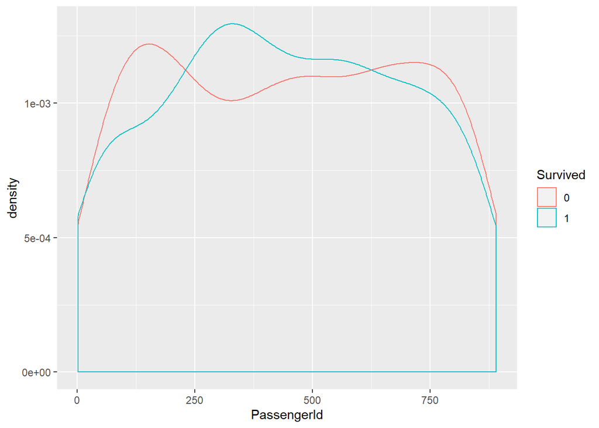

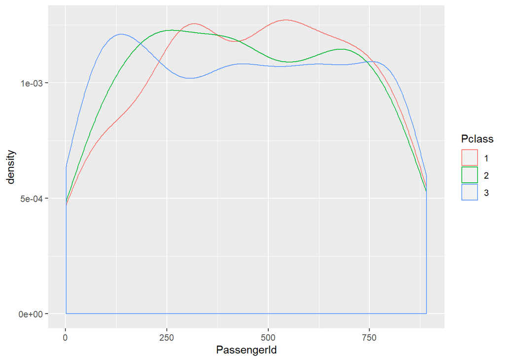

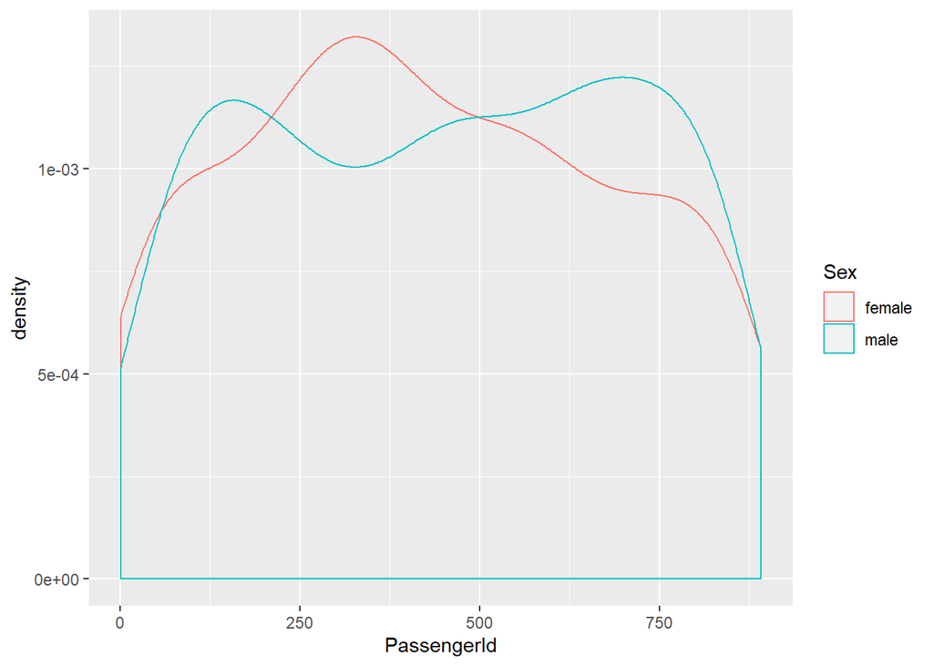

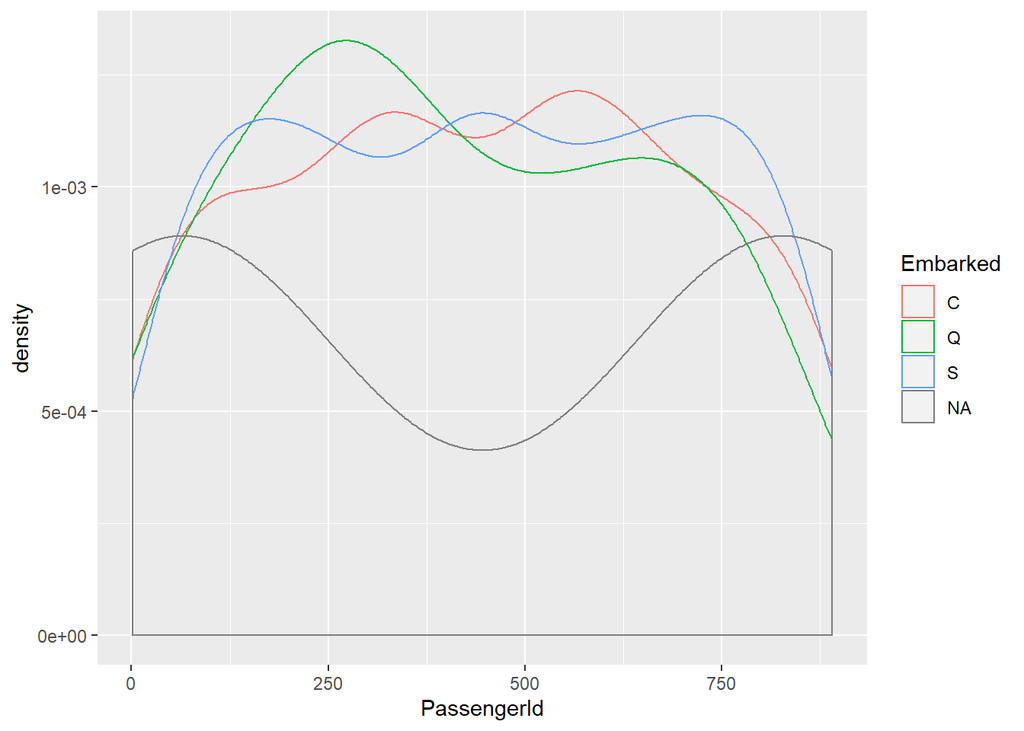

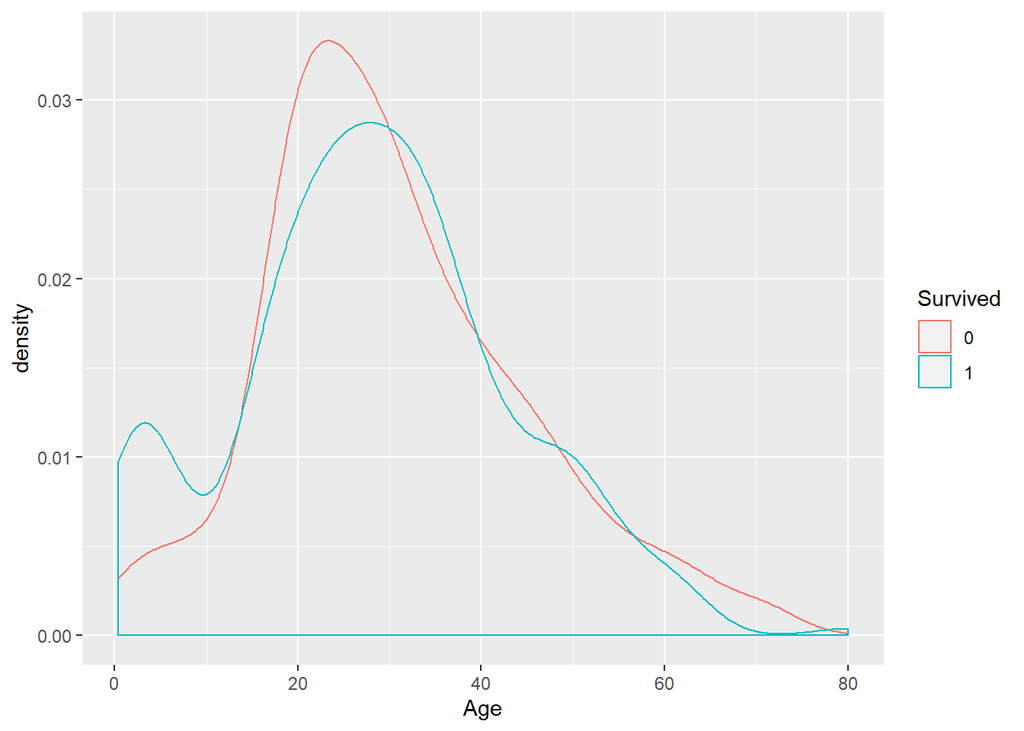

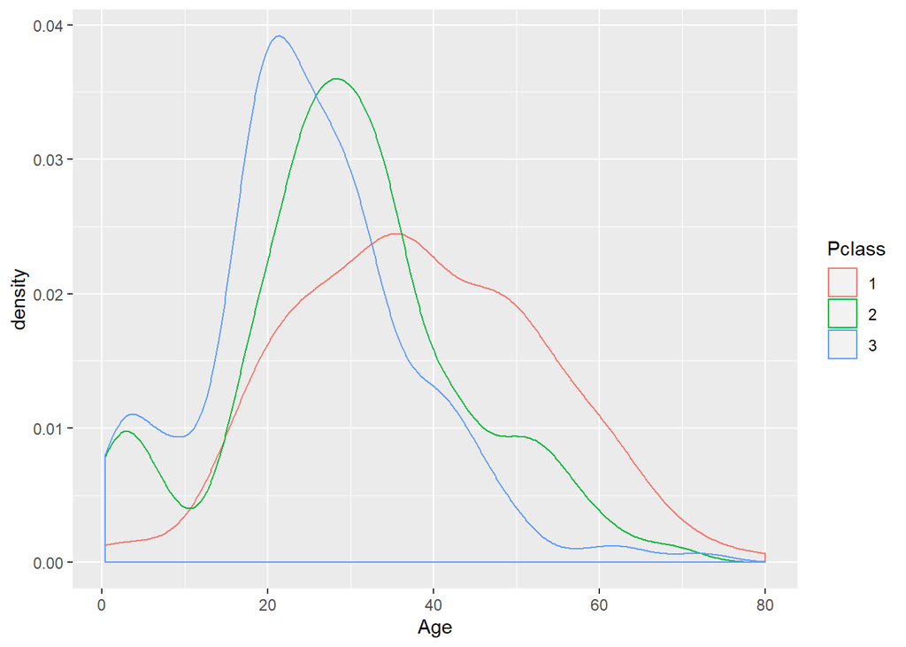

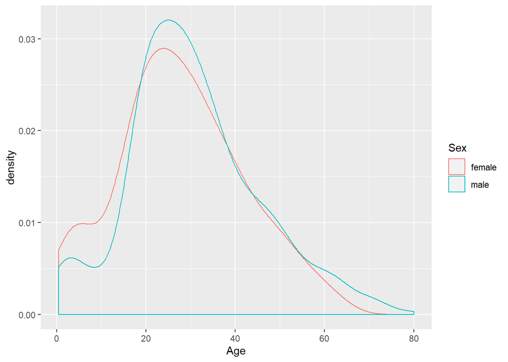

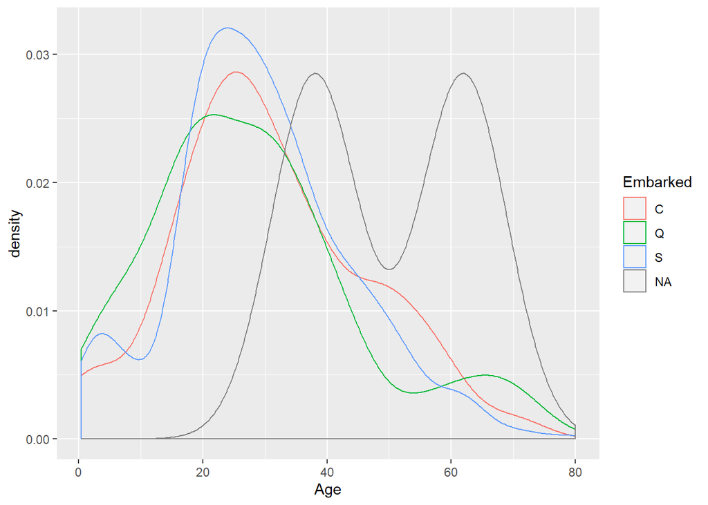

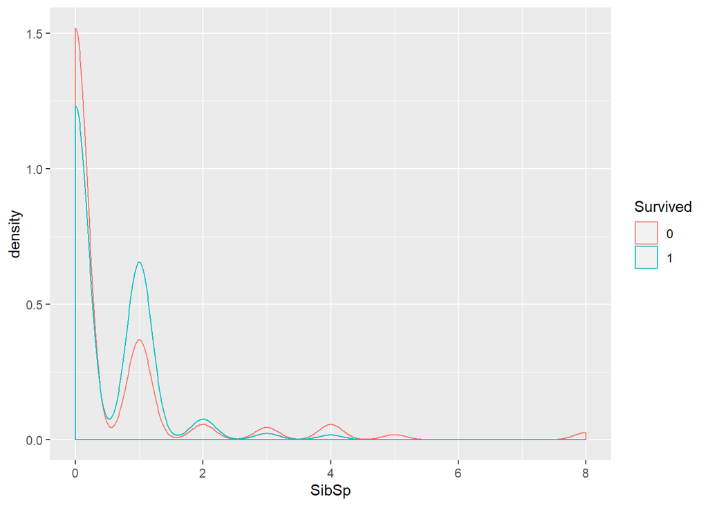

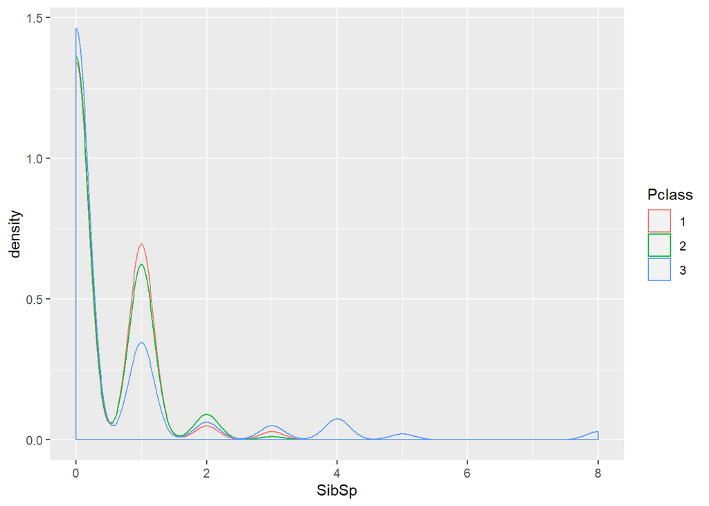

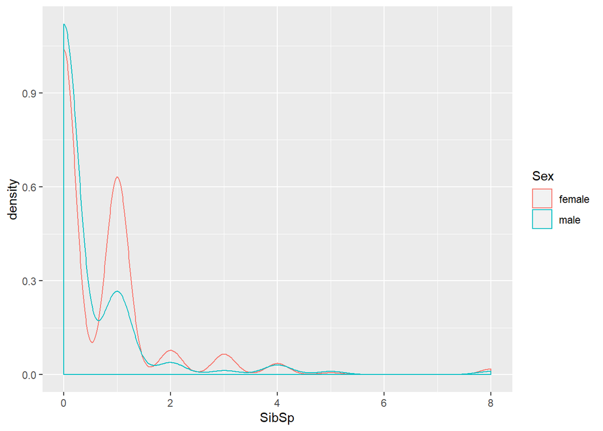

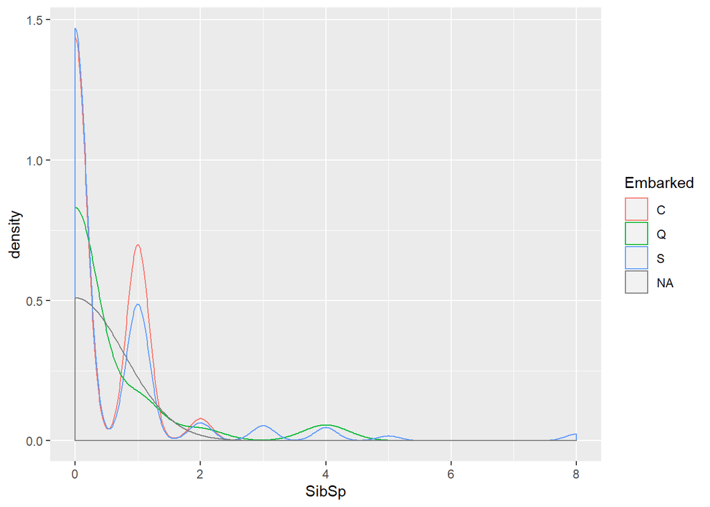

[28 more figures not shown]

```r
redo<- function(d,k) {
  if (k==1) {
    df1 = d[, sapply(d, function(col) length(unique(col))) <= 4]
    map(1:ncol(df1), function(i) {map(1:ncol(df1),function(j) {print(names(df1)[c(i,j)])
      print(ggplot(df1,aes(x = df1[[i]], fill = df1[[j]])) + geom_bar(position = 'dodge')+labs(x = names(df1)[[i]], fill = names(df1)[[j]]))})})
  }
  if (k==2) {
    df1 = d[, sapply(d, function(col) is.numeric(col))]
    map(1:ncol(df1), function(i) { print (names(df1)[i])
      print (ggplot(df1, aes(x = df1[[i]]))+geom_density()+labs(x = names(df1)[[i]]))})
  }
  if (k==3) {
    df1 = d[, sapply(d, function(col) is.numeric(col))]
    df2 = d[, sapply(d, function(col) length(unique(col))) <= 4]
    map(1:ncol(df1), function(i) {map(1:ncol(df2), function(j) {print(ggplot(data=df1,aes(x = df1[[i]]))+geom_density(data = df2, aes(col = df2[[j]]))+labs(x = names(df1)[[i]], col = names(df2)[[j]]))})})
  }
}
redo(titanic,3)
```

7. The function lm computes a linear model. For instance, to do run linear model on the output (y variable) Fare of the input Age (x variable) in the titanic data frame, d, we use # To run a linear model of Fare on Age lm(Fare~Age, d)

# To get the r-square of the linear model

summary(lm(Fare~Age, d))$r.square Write a function, using map, to

input: a data frame output: a data frame of consist three columns x1, x2 and r where the pairs (x1,x2) are all possible pairs of continuous variables of the input data frame and r is the corresponding r square of x1 and x2. Test the function on the titanic data assuming that the PassengerID is also a coninuous variable.

```r
seven<- function(d){
d1 = d%>%select_if(is.numeric)
d2 = data.frame()
  for (i in 1:ncol(d1)) {
    for (j in 1:ncol(d1)) {
      d3 = map_df(d1,~list(
        x1=names(d1)[i],
        x2=names(d1)[j],
        r = round(summary(lm(d1[[j]]~d1[[i]],d1))$r.square,digits = 5)
      ))
      d3 = d3[1,]
      d2=rbind(d2,d3)
  }
}
  return (d2)
}

seven(titanic)
```

```
## # A tibble: 25 x 3
##    x1          x2                r
##    <chr>       <chr>         <dbl>
##  1 PassengerId PassengerId 1
##  2 PassengerId Age         0.00136
##  3 PassengerId SibSp       0.00331
##  4 PassengerId Parch       0
##  5 PassengerId Fare        0.00016
##  6 Age         PassengerId 0.00136
##  7 Age         Age         1
##  8 Age         SibSp       0.0950
##  9 Age         Parch       0.0358
## 10 Age         Fare        0.00923
## # ... with 15 more rows
```